# Accidents à vélo à Nice — Exploration des données BAAC

Auteur·rice

Thelma Panaïotis

Date de publication

9 mars 2026

```r
library(tidyverse)
library(here)
```

## Contexte

Les données proviennent de la **Base de données des Accidents Corporels de la Circulation (BAAC)**, publiée annuellement par le Ministère de l’Intérieur sur [data.gouv.fr](https://www.data.gouv.fr/fr/datasets/bases-de-donnees-annuelles-des-accidents-corporels-de-la-circulation-routiere-annees-de-2005-a-2024/). Elles couvrent l’ensemble des accidents corporels survenus sur les voies ouvertes à la circulation publique en France.

Les données sont organisées en **4 tables** jointes par `Num_Acc` :

| Table | Contenu |
| --- | --- |
| `caracteristiques` | Date, heure, localisation, conditions générales |
| `lieux` | Caractéristiques de la voie (type, profil, surface…) |
| `vehicules` | Véhicules impliqués et leur catégorie |
| `usagers` | Personnes impliquées et leur gravité |

Deux formats coexistent dans les données BAAC : avant 2019, les colonnes `dep`, `com`, `an` et `hrmn` avaient des encodages différents (voir `data-raw/02.read_data.R`). Le script de collecte normalise ces différences.

## Chargement des données

```r
caracteristiques <- readRDS(here("data", "caracteristiques.rds"))
lieux            <- readRDS(here("data", "lieux.rds"))
vehicules        <- readRDS(here("data", "vehicules.rds"))
usagers          <- readRDS(here("data", "usagers.rds"))
```

### Aperçu des tables

```r
cat("caracteristiques :", nrow(caracteristiques), "lignes,", ncol(caracteristiques), "colonnes\n")
```

```
caracteristiques : 14805 lignes, 16 colonnes
```

```r
cat("lieux            :", nrow(lieux),            "lignes,", ncol(lieux),            "colonnes\n")
```

```
lieux            : 14713 lignes, 19 colonnes
```

```r
cat("vehicules        :", nrow(vehicules),         "lignes,", ncol(vehicules),         "colonnes\n")
```

```
vehicules        : 26503 lignes, 11 colonnes
```

```r
cat("usagers          :", nrow(usagers),           "lignes,", ncol(usagers),           "colonnes\n")
```

```
usagers          : 33555 lignes, 17 colonnes
```

```r
glimpse(caracteristiques)
```

```
Rows: 14,805
Columns: 16
$ Num_Acc     <chr> "200500001865", "200500001866", "200500001869", "200500001…
$ an          <int> 2005, 2005, 2005, 2005, 2005, 2005, 2005, 2005, 2005, 2005…
$ mois        <chr> "1", "1", "1", "1", "1", "1", "1", "1", "1", "1", "1", "1"…
$ jour        <chr> "4", "21", "29", "31", "1", "1", "2", "2", "3", "3", "3", …
$ hrmn        <chr> "15:00", "14:30", "20:15", "17:15", "09:00", "10:10", "14:…
$ lum         <chr> "1", "1", "3", "1", "1", "1", "1", "5", "1", "1", "4", "5"…
$ agg         <chr> "1", "1", "1", "1", "2", "2", "2", "2", "2", "2", "2", "2"…
$ int         <chr> "1", "1", "1", "1", "2", "1", "2", "2", "2", "1", "2", "1"…
$ atm         <chr> "1", "1", "8", "1", "1", "1", "1", "1", "1", "1", "1", "1"…
$ col         <chr> "7", "2", "5", "2", "3", "2", "3", "3", "3", "4", "3", "1"…
$ com         <chr> "06088", "06088", "06088", "06088", "06088", "06088", "060…
$ adr         <chr> NA, NA, NA, NA, "10, RAIMBALDI (BD)", "213, ANGLAIS (DU N\…
$ lat         <dbl> NA, NA, NA, NA, NA, NA, NA, NA, NA, NA, NA, NA, NA, NA, NA…
$ long        <dbl> NA, NA, NA, NA, NA, NA, NA, NA, NA, NA, NA, NA, NA, NA, NA…
$ dep         <int> 6, 6, 6, 6, 6, 6, 6, 6, 6, 6, 6, 6, 6, 6, 6, 6, 6, 6, 6, 6…
$ Accident_Id <chr> NA, NA, NA, NA, NA, NA, NA, NA, NA, NA, NA, NA, NA, NA, NA…
```

### Harmonisation des types

Les tables secondaires (lieux, véhicules, usagers) sont lues en `character` depuis les CSVs bruts pour les années sans API Tabular. On convertit les colonnes clés.

```r
vehicules <- vehicules %>%
  mutate(
    Num_Acc = as.character(Num_Acc),
    catv    = as.integer(catv)
  )

usagers <- usagers %>%
  mutate(
    Num_Acc  = as.character(Num_Acc),
    grav     = as.integer(grav),
    catu     = as.integer(catu),
    sexe     = as.integer(sexe),
    an_nais  = as.integer(an_nais)
  )

lieux <- lieux %>%
  mutate(Num_Acc = as.character(Num_Acc))

caracteristiques <- caracteristiques %>%
  mutate(Num_Acc = as.character(Num_Acc))
```

## Accidents impliquant un vélo

On identifie les accidents où au moins un véhicule est une **bicyclette** (`catv == 1`) ou un **vélo à assistance électrique** (`catv == 80`, présent à partir de 2016 environ).

```r
# Num_Acc des accidents impliquant un vélo
acc_velo <- vehicules %>%
  filter(catv %in% c(1, 80)) %>%
  pull(Num_Acc) %>%
  unique()

cat("Accidents impliquant un vélo :", length(acc_velo), "\n")
```

```
Accidents impliquant un vélo : 542
```

```r
cat("Sur", n_distinct(caracteristiques$Num_Acc), "accidents corporels au total à Nice\n")
```

```
Sur 14618 accidents corporels au total à Nice
```

```r
cat("Soit", round(length(acc_velo) / n_distinct(caracteristiques$Num_Acc) * 100, 1), "%\n")
```

```
Soit 3.7 %
```

```r
caract_velo   <- caracteristiques %>% filter(Num_Acc %in% acc_velo)
lieux_velo    <- lieux            %>% filter(Num_Acc %in% acc_velo)
vehicules_velo <- vehicules       %>% filter(Num_Acc %in% acc_velo)
usagers_velo  <- usagers          %>% filter(Num_Acc %in% acc_velo)
```

## Évolution temporelle

### Tous les accidents corporels vs. accidents vélo

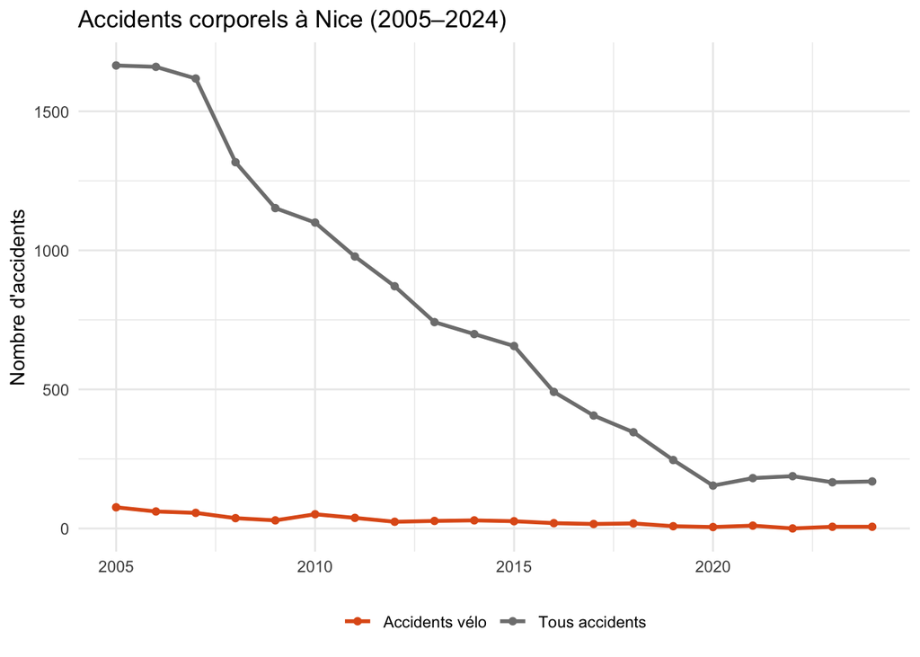

```r
total_par_an <- caracteristiques %>% count(an, name = "total")
velo_par_an  <- caract_velo %>% count(an, name = "velo")

evolution <- total_par_an %>%
  left_join(velo_par_an, by = "an") %>%
  mutate(
    velo  = replace_na(velo, 0),
    pct   = velo / total * 100
  )

evolution %>%
  pivot_longer(c(total, velo), names_to = "type", values_to = "n") %>%
  mutate(type = recode(type, total = "Tous accidents", velo = "Accidents vélo")) %>%
  ggplot(aes(x = an, y = n, colour = type)) +
  geom_line(linewidth = 1) +
  geom_point() +
  scale_colour_manual(values = c("Tous accidents" = "grey50", "Accidents vélo" = "#e05c1a")) +
  labs(
    title  = "Accidents corporels à Nice (2005–2024)",
    x      = NULL, y = "Nombre d'accidents", colour = NULL
  ) +
  theme_minimal() +
  theme(legend.position = "bottom")
```

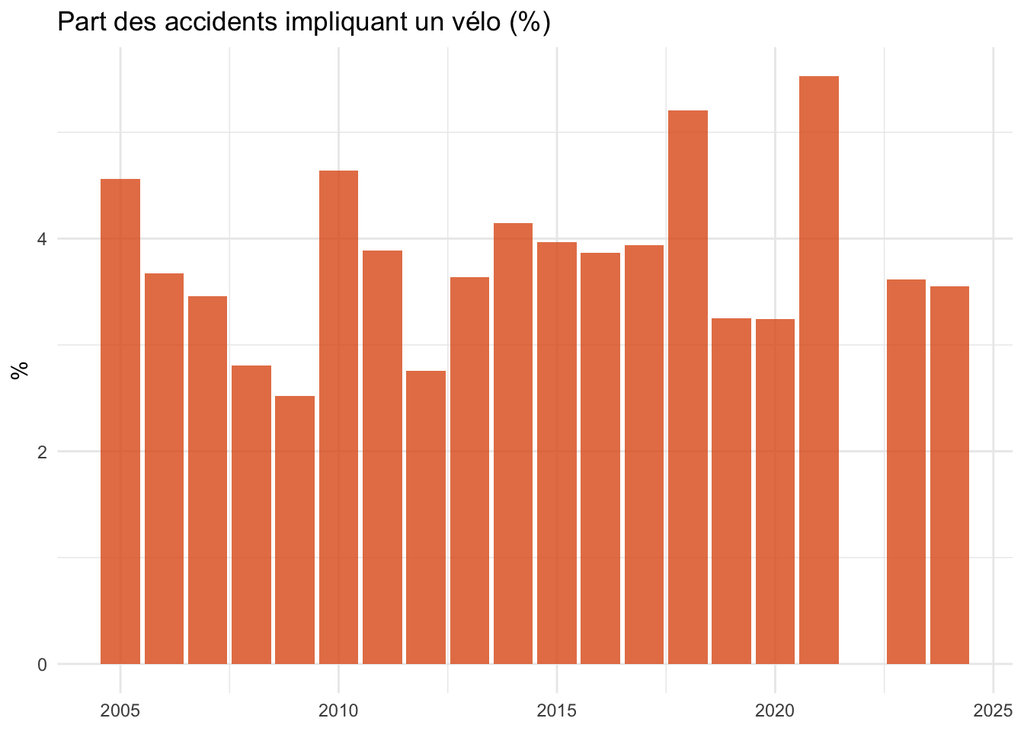

```r
ggplot(evolution, aes(x = an, y = pct)) +
  geom_col(fill = "#e05c1a", alpha = 0.8) +
  labs(
    title = "Part des accidents impliquant un vélo (%)",
    x = NULL, y = "%"
  ) +
  theme_minimal()
```

### Saisonnalité (accidents vélo)

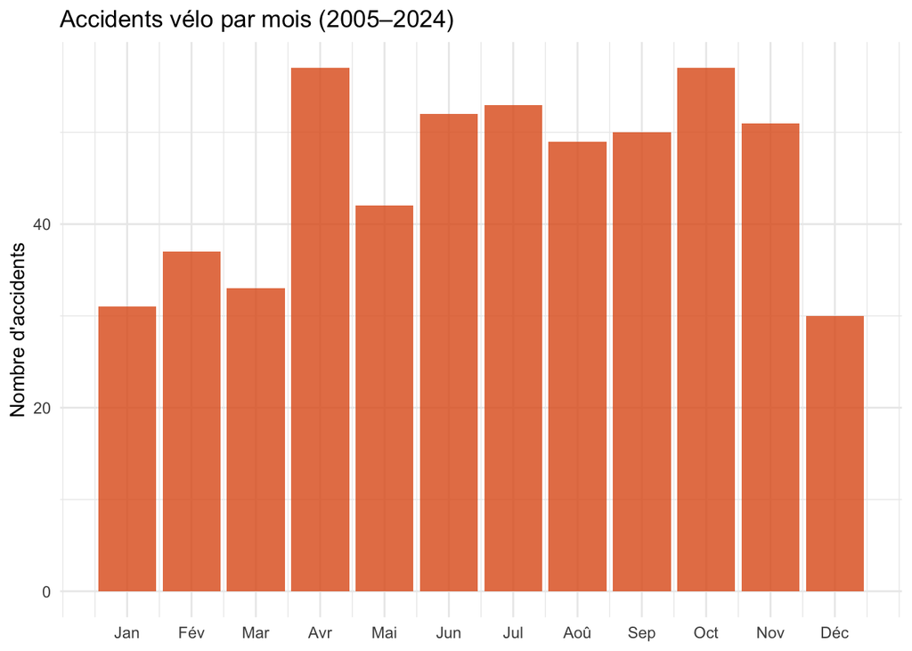

```r
mois_labels <- c("Jan", "Fév", "Mar", "Avr", "Mai", "Jun",
                 "Jul", "Aoû", "Sep", "Oct", "Nov", "Déc")

caract_velo %>%
  mutate(mois = as.integer(mois)) %>%
  count(mois) %>%
  ggplot(aes(x = mois, y = n)) +
  geom_col(fill = "#e05c1a", alpha = 0.8) +
  scale_x_continuous(breaks = 1:12, labels = mois_labels) +
  labs(title = "Accidents vélo par mois (2005–2024)", x = NULL, y = "Nombre d'accidents") +
  theme_minimal()
```

### Jour de la semaine

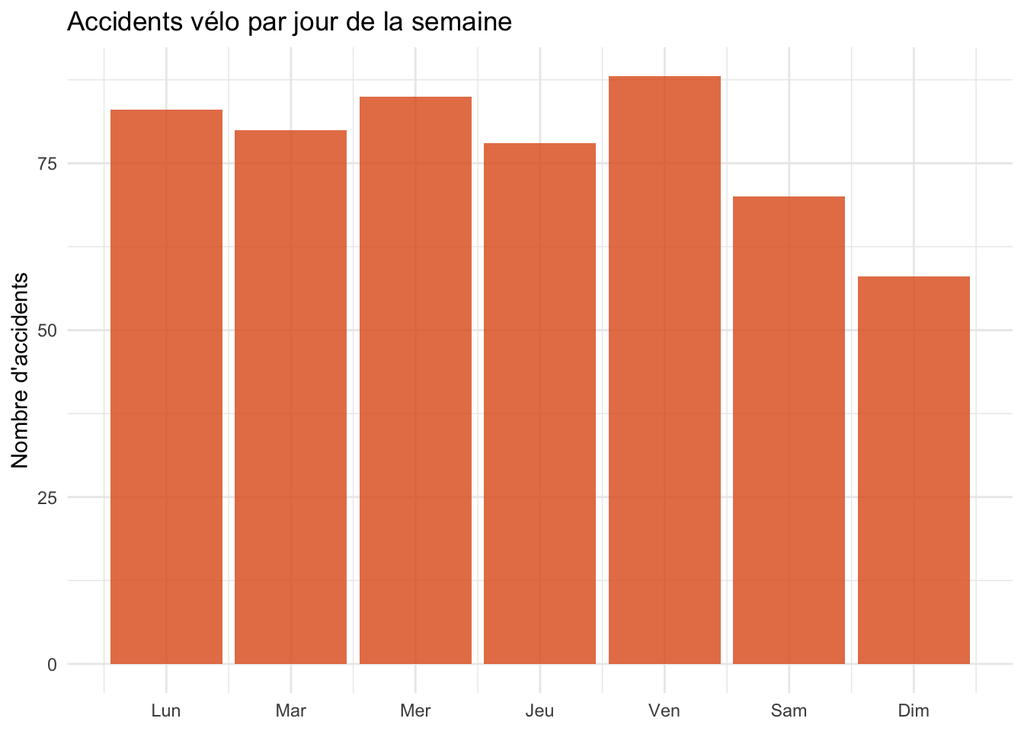

```r
jour_labels <- c("Lun", "Mar", "Mer", "Jeu", "Ven", "Sam", "Dim")

caract_velo %>%
  mutate(
    date     = make_date(as.integer(an), as.integer(mois), as.integer(jour)),
    jour_sem = wday(date, week_start = 1)  # 1=lundi ... 7=dimanche
  ) %>%
  count(jour_sem) %>%
  ggplot(aes(x = jour_sem, y = n)) +
  geom_col(fill = "#e05c1a", alpha = 0.8) +
  scale_x_continuous(breaks = 1:7, labels = jour_labels) +
  labs(title = "Accidents vélo par jour de la semaine", x = NULL, y = "Nombre d'accidents") +
  theme_minimal()
```

### Heure de la journée

Les données d’heure (`hrmn`) sont disponibles pour 2018 et antérieur, et pour 2024. Elles sont manquantes (bug API Tabular) pour 2019–2023.

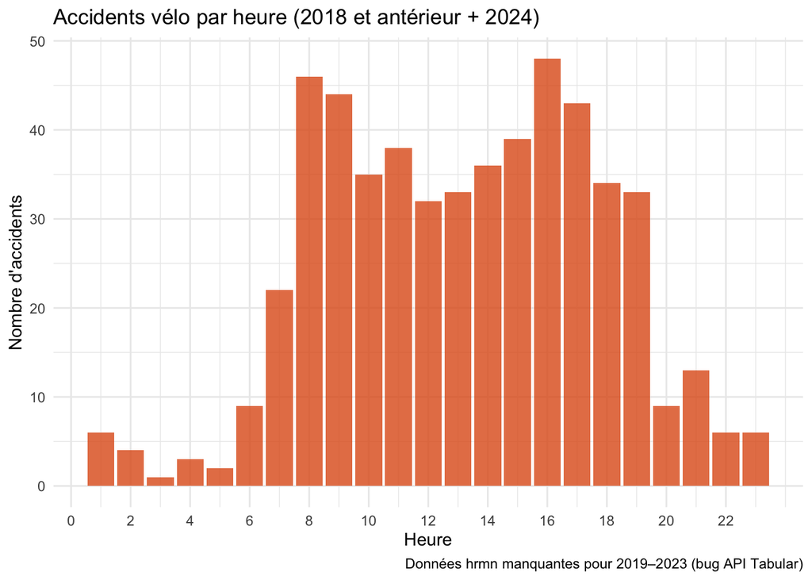

```r
caract_velo %>%
  filter(!is.na(hrmn), str_detect(hrmn, "^\\d{2}:\\d{2}$")) %>%
  mutate(heure = as.integer(substr(hrmn, 1, 2))) %>%
  count(heure) %>%
  ggplot(aes(x = heure, y = n)) +
  geom_col(fill = "#e05c1a", alpha = 0.8) +
  scale_x_continuous(breaks = seq(0, 23, 2)) +
  labs(
    title   = "Accidents vélo par heure (2018 et antérieur + 2024)",
    caption = "Données hrmn manquantes pour 2019–2023 (bug API Tabular)",
    x = "Heure", y = "Nombre d'accidents"
  ) +
  theme_minimal()
```

## Gravité des accidents

Les usagers sont classés selon 4 niveaux de gravité (`grav`) :

| Code | Libellé |
| --- | --- |
| 1 | Indemne |
| 2 | Tué |
| 3 | Blessé hospitalisé |
| 4 | Blessé léger |

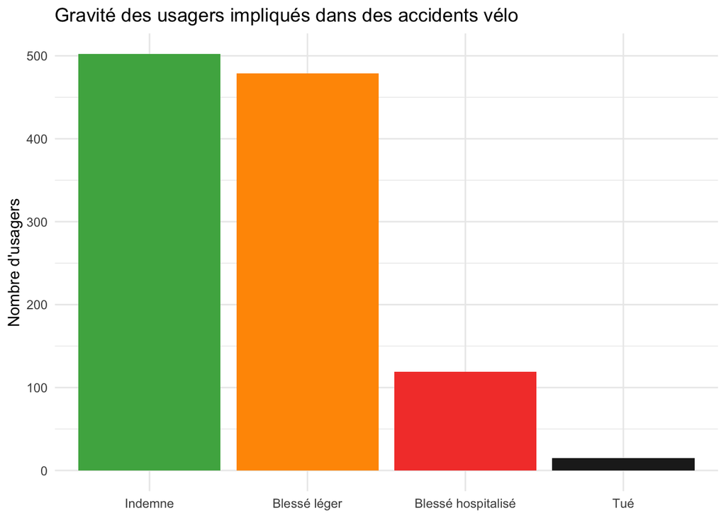

```r
grav_labels <- c("1" = "Indemne", "2" = "Tué", "3" = "Blessé hospitalisé", "4" = "Blessé léger")

usagers_velo %>%
  mutate(grav_label = recode(as.character(grav), !!!grav_labels)) %>%
  count(grav_label) %>%
  mutate(grav_label = fct_reorder(grav_label, n, .desc = TRUE)) %>%
  ggplot(aes(x = grav_label, y = n, fill = grav_label)) +
  geom_col(show.legend = FALSE) +
  scale_fill_manual(values = c(
    "Indemne"             = "#4caf50",
    "Blessé léger"        = "#ff9800",
    "Blessé hospitalisé"  = "#f44336",
    "Tué"                 = "#212121"
  )) +
  labs(title = "Gravité des usagers impliqués dans des accidents vélo", x = NULL, y = "Nombre d'usagers") +
  theme_minimal()
```

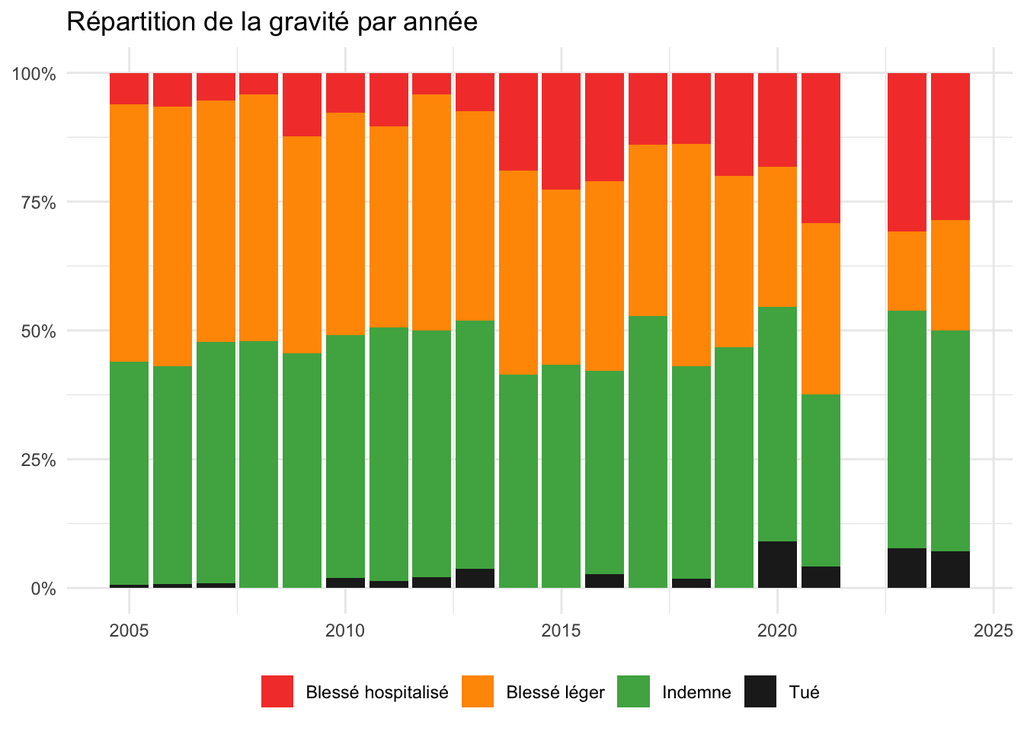

```r
usagers_velo %>%
  left_join(caract_velo %>% select(Num_Acc, an), by = "Num_Acc") %>%
  mutate(grav_label = recode(as.character(grav), !!!grav_labels)) %>%
  count(an, grav_label) %>%
  filter(!is.na(grav_label)) %>%
  ggplot(aes(x = an, y = n, fill = grav_label)) +
  geom_col(position = "fill") +
  scale_fill_manual(values = c(
    "Indemne"             = "#4caf50",
    "Blessé léger"        = "#ff9800",
    "Blessé hospitalisé"  = "#f44336",
    "Tué"                 = "#212121"
  )) +
  scale_y_continuous(labels = scales::percent) +
  labs(
    title = "Répartition de la gravité par année",
    x = NULL, y = NULL, fill = NULL
  ) +
  theme_minimal() +
  theme(legend.position = "bottom")
```

## Cartographie

```r
# Diagnostic : distribution de lat/long dans caract_velo
cat("Résumé lat :\n"); print(summary(caract_velo$lat))
```

```
Résumé lat :
```

```
   Min. 1st Qu.  Median    Mean 3rd Qu.    Max.    NA's
     NA      NA      NA     NaN      NA      NA     542
```

```r
cat("Résumé long :\n"); print(summary(caract_velo$long))
```

```
Résumé long :
```

```
   Min. 1st Qu.  Median    Mean 3rd Qu.    Max.    NA's
     NA      NA      NA     NaN      NA      NA     542
```

```r
cat("Années avec lat non-NA :", caract_velo %>% filter(!is.na(lat)) %>% pull(an) %>% unique() %>% sort(), "\n")
```

```
Années avec lat non-NA :
```

```r
caract_velo_geo <- caract_velo %>%
  filter(!is.na(lat), !is.na(long), lat != 0, long != 0)

cat("Accidents vélo géolocalisés :", nrow(caract_velo_geo), "/", nrow(caract_velo), "\n")
```

```
Accidents vélo géolocalisés : 0 / 542
```

```r
if (nrow(caract_velo_geo) > 0) {
  library(leaflet)
  leaflet(caract_velo_geo) %>%
    addTiles() %>%
    addCircleMarkers(
      lng      = ~long,
      lat      = ~lat,
      radius   = 5,
      color    = "#e05c1a",
      stroke   = FALSE,
      fillOpacity = 0.7,
      popup    = ~paste0("<b>", an, "</b><br>", adr)
    )
}
```

## Conditions des accidents

### Luminosité

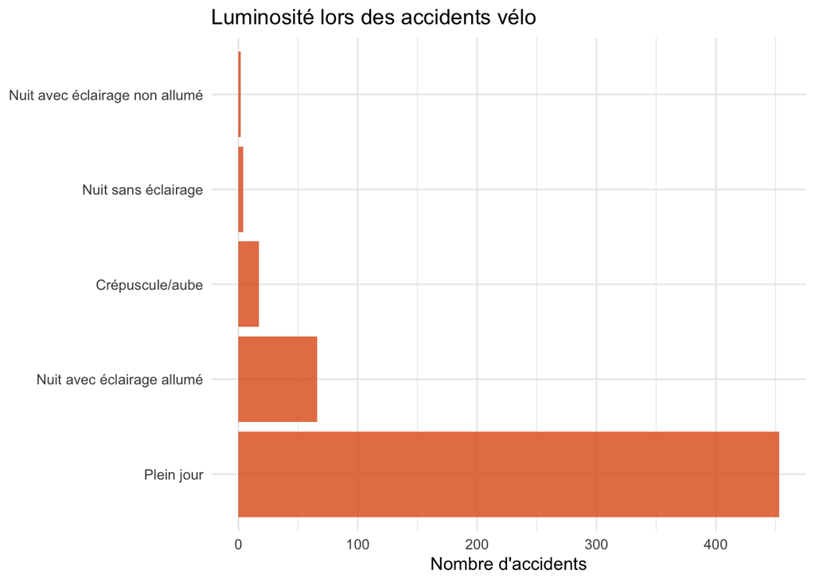

```r
lum_labels <- c(
  "1" = "Plein jour", "2" = "Crépuscule/aube",
  "3" = "Nuit sans éclairage", "4" = "Nuit avec éclairage non allumé",
  "5" = "Nuit avec éclairage allumé"
)

caract_velo %>%
  mutate(lum_label = recode(as.character(lum), !!!lum_labels)) %>%
  count(lum_label) %>%
  mutate(lum_label = fct_reorder(lum_label, n, .desc = TRUE)) %>%
  ggplot(aes(x = lum_label, y = n)) +
  geom_col(fill = "#e05c1a", alpha = 0.8) +
  coord_flip() +
  labs(title = "Luminosité lors des accidents vélo", x = NULL, y = "Nombre d'accidents") +
  theme_minimal()
```

### Type de collision

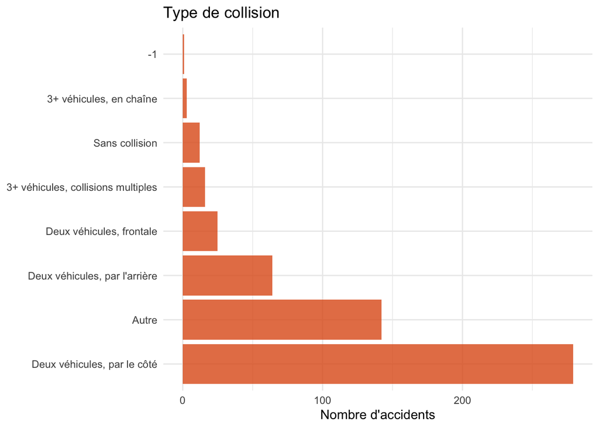

```r
col_labels <- c(
  "1" = "Deux véhicules, frontale", "2" = "Deux véhicules, par l'arrière",
  "3" = "Deux véhicules, par le côté", "4" = "3+ véhicules, en chaîne",
  "5" = "3+ véhicules, collisions multiples", "6" = "Autre", "7" = "Sans collision"
)

caract_velo %>%
  mutate(col_label = recode(as.character(col), !!!col_labels)) %>%
  count(col_label) %>%
  mutate(col_label = fct_reorder(col_label, n, .desc = TRUE)) %>%
  ggplot(aes(x = col_label, y = n)) +
  geom_col(fill = "#e05c1a", alpha = 0.8) +
  coord_flip() +
  labs(title = "Type de collision", x = NULL, y = "Nombre d'accidents") +
  theme_minimal()
```

### Infrastructure (table lieux)

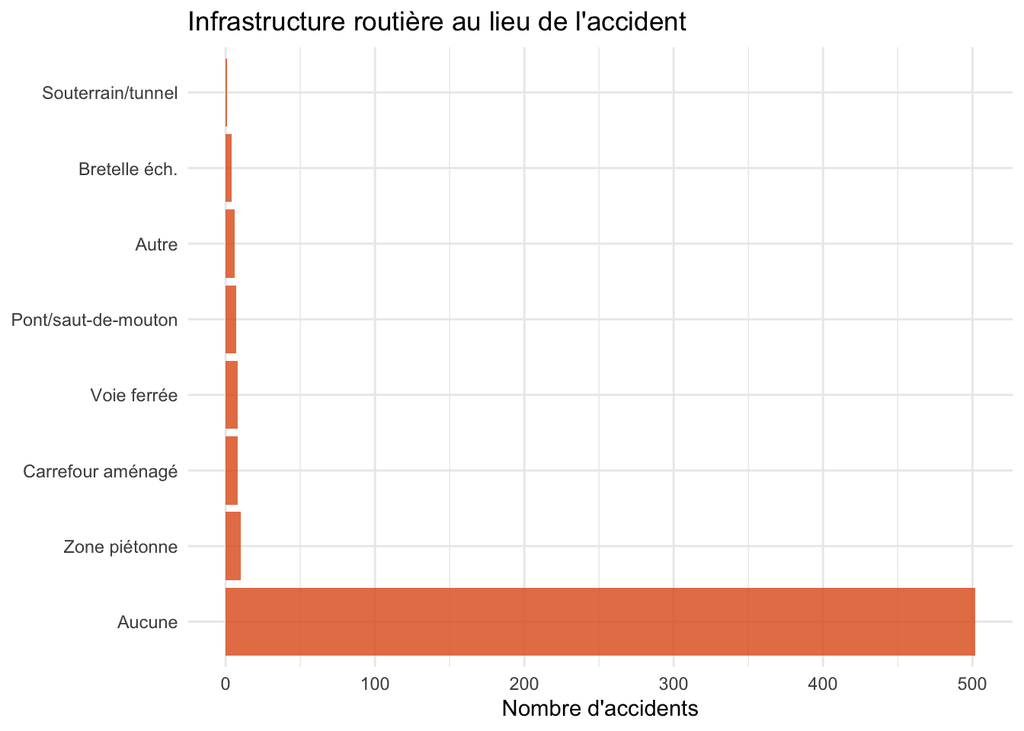

```r
infra_labels <- c(
  "0" = "Aucune",        "1" = "Souterrain/tunnel", "2" = "Pont/saut-de-mouton",
  "3" = "Bretelle éch.", "4" = "Voie ferrée",        "5" = "Carrefour aménagé",
  "6" = "Zone piétonne", "7" = "Zone de péage",      "8" = "Chantier",
  "9" = "Autre"
)

lieux_velo %>%
  mutate(infra_label = recode(as.character(infra), !!!infra_labels)) %>%
  count(infra_label) %>%
  mutate(infra_label = fct_reorder(infra_label, n, .desc = TRUE)) %>%
  ggplot(aes(x = infra_label, y = n)) +
  geom_col(fill = "#e05c1a", alpha = 0.8) +
  coord_flip() +
  labs(title = "Infrastructure routière au lieu de l'accident", x = NULL, y = "Nombre d'accidents") +
  theme_minimal()
```

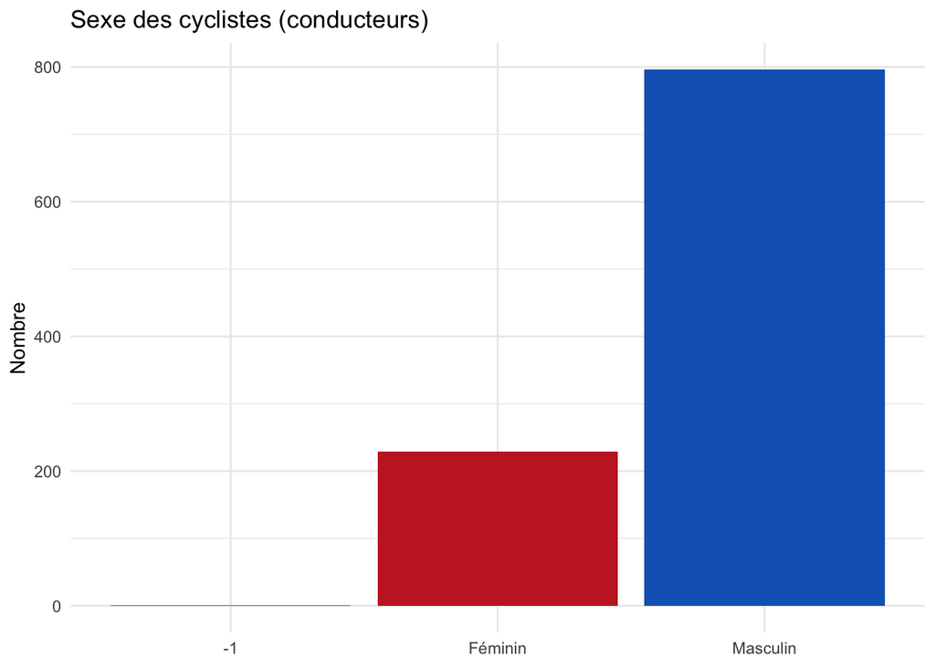

```r
usagers_velo %>%
  filter(catu == 1) %>%   # conducteurs seulement (catu 1 = conducteur)
  mutate(sexe_label = recode(as.character(sexe), "1" = "Masculin", "2" = "Féminin")) %>%
  filter(!is.na(sexe_label)) %>%
  count(sexe_label) %>%
  ggplot(aes(x = sexe_label, y = n, fill = sexe_label)) +
  geom_col(show.legend = FALSE) +
  scale_fill_manual(values = c("Masculin" = "#1565c0", "Féminin" = "#c62828")) +
  labs(title = "Sexe des cyclistes (conducteurs)", x = NULL, y = "Nombre") +
  theme_minimal()
```

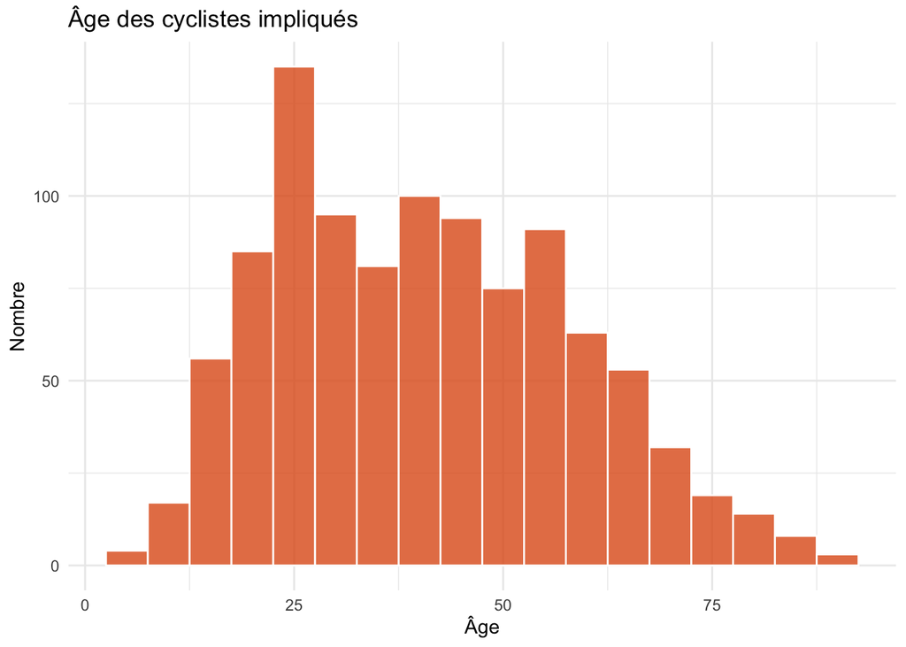

```r
usagers_velo %>%
  filter(catu == 1, !is.na(an_nais), an_nais > 1900) %>%
  left_join(caract_velo %>% select(Num_Acc, an), by = "Num_Acc") %>%
  mutate(age = an - an_nais) %>%
  filter(age >= 0, age <= 100) %>%
  ggplot(aes(x = age)) +
  geom_histogram(binwidth = 5, fill = "#e05c1a", alpha = 0.8, colour = "white") +
  labs(title = "Âge des cyclistes impliqués", x = "Âge", y = "Nombre") +
  theme_minimal()
```